# fpo

Απο εδώ αρχίζει το evaluate function , αρχικά διάγραμμα για ένα less sparse με μια μεγάλη τιμή πχ 1000(bv = big value)

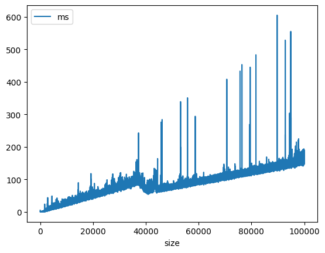

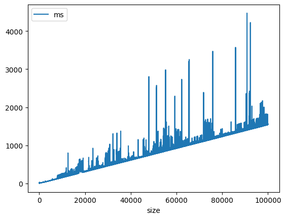

```python
df = pd.read_csv('results/evaluate_bv_tree_ls.csv')
df.plot(x='size' , y='ms')

#for the vector
df_v = pd.read_csv('results/evaluate_bv_v_ls.csv')
df_v.plot(x='size' , y='ms')
```

εδώ έχεις το ίδιο με πριν αλλά με μια μικρή τιμή πχ 20

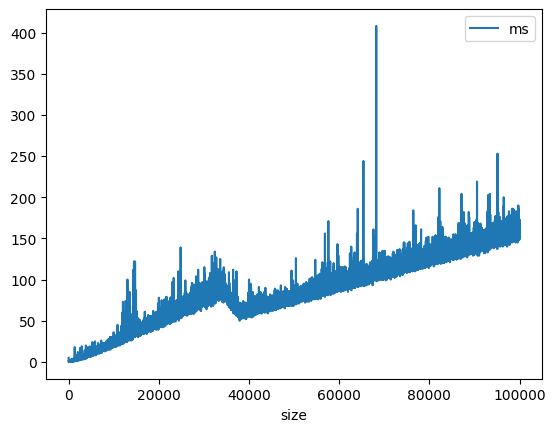

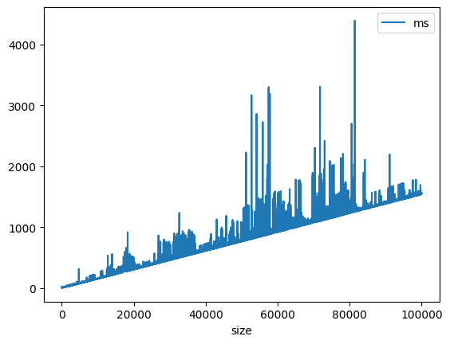

```python
df = pd.read_csv('results/evaluate_sv_tree_ls.csv')
df.plot(x='size' , y='ms')

#for the vector
df_v = pd.read_csv('results/evaluate_sv_v_ls.csv')
df_v.plot(x='size' , y='ms')
```

Εδώ έχεις για ένα full sparse με μια μεγάλη τιμή πχ 1000

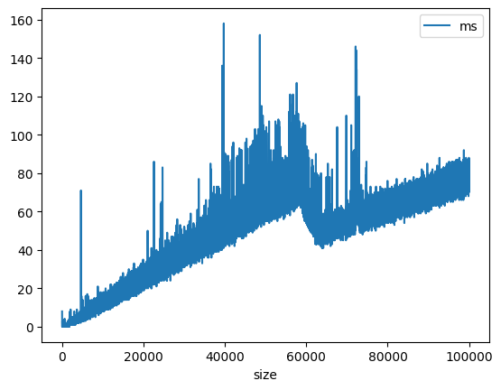

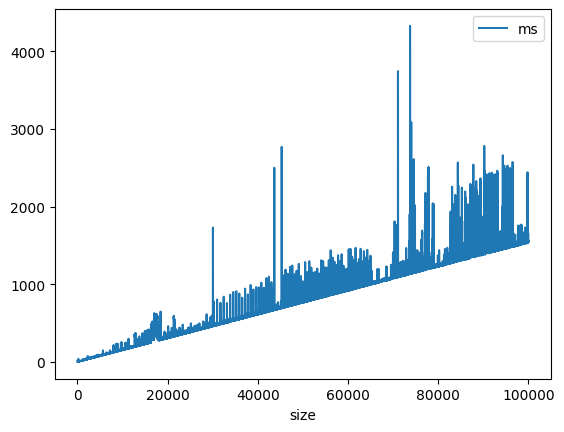

```python
df = pd.read_csv('results/evaluate_bv_tree_fs.csv')
df.plot(x='size' , y='ms')

#for the vector
df_v = pd.read_csv('results/evaluate_bv_v_fs.csv')
df_v.plot(x='size' , y='ms')
```

Παρακάτω έχεις το ίδιο για μια μικρή τιμή πχ 20.

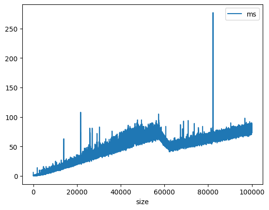

```python
df = pd.read_csv('results/evaluate_sv_tree_fs.csv')
df.plot(x='size' , y='ms')

#δεν χρειαζεται να το ξαναυπολογισω κουραστηκα
```

Παρακάτω έχεις το evaluate για ενα normal με μια μικρή τιμη(εβαλα 10)

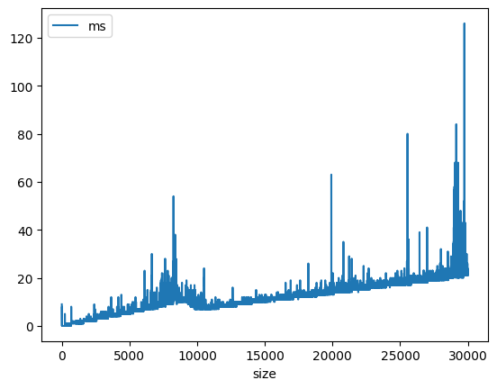

```python
df = pd.read_csv('results/evaluate_sv_tree_normal.csv')
df.plot(x='size' , y='ms')
```

Παρακάτω έχεις το evaluate για ενα normal με μια πιο μεγαλη τιμη(εβαλα 100 μην ξεφτιλισουμε τον υπολογιστή μου)

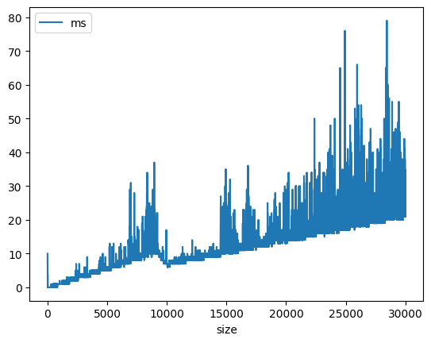

```python
df = pd.read_csv('results/evaluate_bv_tree_normal.csv')
df.plot(x='size' , y='ms')
```

Επισης επισημανω οτι δεν χρειαζεται να ελεγξω την αφαιρεση γιατι ειναι το ιδιο με την προσθεση. Με λιγα λογια στον πολλαπλασιασμο τον τερματισα τον πινακα , rip στον υπολογιστακο μου

Οτιδηποτε αλλο θελεις πες μου.